# CASA0005 第三周：投影、WorldClim、空间提取和描述统计

按[官方第 3 章](https://andrewmaclachlan.github.io/CASA0005repo/spatial-descriptive-statistics.html)顺序整理CRS、栅格提取与描述统计。打开课程 `casa0005.Rproj`，代码按顺序运行；Knit 从头计算普通分析块；安装、导出与可选联网分支单独执行。

来源：MacLachlan、Dennett、Dooley；[CC BY-SA 4.0](https://creativecommons.org/licenses/by-sa/4.0/)。中文整理与适配经 AI 辅助，见改编范围；源版本 `0b19a3339034e3bd3de1e8246559d453301f07eb`。

## 数据与包

GADM Australia 存为 `data/raw/week03/gadm41_AUS.gpkg`；WorldClim v2.1 的 12 个 tavg、5 角分 TIFF 存入 `data/raw/week03/worldclim/`。基准期 1970–2000，单位 °C，`5m` 为角分。来源与校验见 数据记录。本机包安装至被忽略的 `.local-review/R-library`；仅补缺包，binary 安装适配 Mac。

```r
helper <- c("tutorial-tools.R", "../tutorial-tools.R")
source(helper[file.exists(helper)][1])
root <- gis_root()
local_lib <- file.path(root, ".local-review", "R-library")
dir.create(local_lib, recursive = TRUE, showWarnings = FALSE)
.libPaths(c(local_lib, .libPaths()))
required_packages <- c("sf", "terra", "tidyverse", "fs", "tidyterra", "plotly")
missing_packages <- required_packages[
  !vapply(required_packages, requireNamespace, logical(1), quietly = TRUE)]
if (length(missing_packages)) {
  options(timeout = max(1200, getOption("timeout")))
  install.packages(missing_packages, lib = local_lib,
                   repos = "https://cloud.r-project.org", type = "binary")
}
```

## 加载工具

新会话先加载工具，恢复本地包库路径。

```r
helper <- c("tutorial-tools.R", "../tutorial-tools.R")
source(helper[file.exists(helper)][1])
root <- gis_root()
local_lib <- file.path(root, ".local-review", "R-library")
if (dir.exists(local_lib)) .libPaths(c(local_lib, .libPaths()))
gis_packages(c("sf", "terra", "tidyverse", "fs"))
library(sf)
library(terra)
library(tidyverse)
```

## 3.5.1 矢量 CRS

读取以 `_0` 结尾的国家层。4326 为经纬度，3112 为澳大利亚米制 Lambert 投影。

```r
aus_file <- gis_file("data/raw/week03/gadm41_AUS.gpkg", "^gadm41_AUS\\.gpkg$")
layers <- st_layers(aus_file)
layers
```

```
## Driver: GPKG
## Available layers:
##   layer_name geometry_type features fields crs_name
## 1  ADM_ADM_0 Multi Polygon        1      2   WGS 84
## 2  ADM_ADM_1 Multi Polygon       11     11   WGS 84
## 3  ADM_ADM_2 Multi Polygon      568     13   WGS 84
```

```r
aus_layer <- layers$name[grepl("_0$", layers$name)]
stopifnot(length(aus_layer) == 1)
Ausoutline <- st_read(aus_file, layer = aus_layer, quiet = TRUE)
print(Ausoutline)
```

```
## Simple feature collection with 1 feature and 2 fields
## Geometry type: MULTIPOLYGON
## Dimension:     XY
## Bounding box:  xmin: 112.9211 ymin: -55.11694 xmax: 159.1092 ymax: -9.142176
## Geodetic CRS:  WGS 84
##   GID_0   COUNTRY                           geom
## 1   AUS Australia MULTIPOLYGON (((158.6876 -5...
```

```r
st_crs(Ausoutline)
```

```
## Coordinate Reference System:
##   User input: WGS 84
##   wkt:
## GEOGCRS["WGS 84",
##     ENSEMBLE["World Geodetic System 1984 ensemble",
##         MEMBER["World Geodetic System 1984 (Transit)"],
##         MEMBER["World Geodetic System 1984 (G730)"],
##         MEMBER["World Geodetic System 1984 (G873)"],
##         MEMBER["World Geodetic System 1984 (G1150)"],
##         MEMBER["World Geodetic System 1984 (G1674)"],
##         MEMBER["World Geodetic System 1984 (G1762)"],
##         MEMBER["World Geodetic System 1984 (G2139)"],
##         MEMBER["World Geodetic System 1984 (G2296)"],
##         ELLIPSOID["WGS 84",6378137,298.257223563,
##             LENGTHUNIT["metre",1]],
##         ENSEMBLEACCURACY[2.0]],
##     PRIMEM["Greenwich",0,
##         ANGLEUNIT["degree",0.0174532925199433]],
##     CS[ellipsoidal,2],
##         AXIS["geodetic latitude (Lat)",north,
##             ORDER[1],
##             ANGLEUNIT["degree",0.0174532925199433]],
##         AXIS["geodetic longitude (Lon)",east,
##             ORDER[2],
##             ANGLEUNIT["degree",0.0174532925199433]],
##     USAGE[
##         SCOPE["Horizontal component of 3D system."],
##         AREA["World."],
##         BBOX[-90,-180,90,180]],
##     ID["EPSG",4326]]
```

```r
st_crs(Ausoutline)$proj4string
```

```
## [1] "+proj=longlat +datum=WGS84 +no_defs"
```

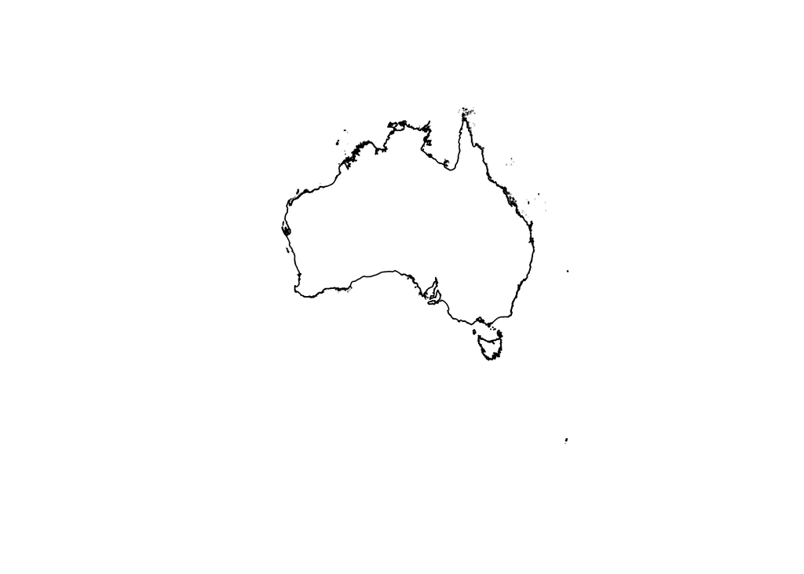

```r
plot(st_geometry(Ausoutline))
```

## 转换坐标

`st_transform()` 计算新坐标；`st_set_crs()` 仅设置标签，缺失 CRS 需查元数据。

```r
stopifnot(!is.na(st_crs(Ausoutline)))
AusoutlinePROJECTED <- st_transform(Ausoutline, 3112)
st_bbox(Ausoutline)
```

```
##       xmin       ymin       xmax       ymax
## 112.921112 -55.116943 159.109222  -9.142176
```

```r
st_bbox(AusoutlinePROJECTED)
```

```
##     xmin     ymin     xmax     ymax
## -2083066 -6460625  2346599 -1115905
```

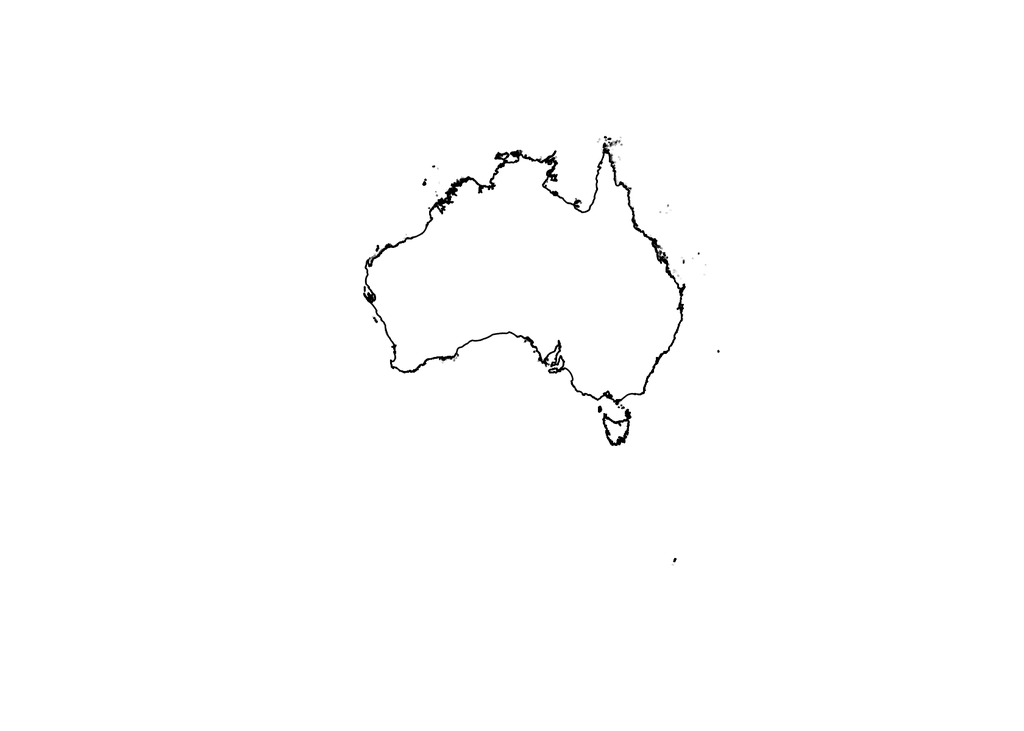

```r
plot(st_geometry(AusoutlinePROJECTED))
```

```r
AusoutlineSP <- as(Ausoutline, "Spatial")
AusoutlineSF <- st_as_sf(AusoutlineSP)
```

## 3.5.2 读取一月栅格

检查层、范围、分辨率和 CRS。

```r
jan_file <- gis_file("data/raw/week03/worldclim/wc2.1_5m_tavg_01.tif", "^wc2\\.1_5m_tavg_01\\.tif$")
jan <- terra::rast(jan_file)
jan
```

```
## class       : SpatRaster
## size        : 2160, 4320, 1  (nrow, ncol, nlyr)
## resolution  : 0.08333333, 0.08333333  (x, y)
## extent      : -180, 180, -90, 90  (xmin, xmax, ymin, ymax)
## coord. ref. : lon/lat WGS 84 (EPSG:4326)
## source      : wc2.1_5m_tavg_01.tif
## name        : wc2.1_5m_tavg_01
## min value   :       -46.041999
## max value   :        34.064999
```

```r
terra::res(jan)
```

```
## [1] 0.08333333 0.08333333
```

```r
terra::crs(jan)
```

```
## [1] "GEOGCRS[\"WGS 84\",\n    ENSEMBLE[\"World Geodetic System 1984 ensemble\",\n        MEMBER[\"World Geodetic System 1984 (Transit)\"],\n        MEMBER[\"World Geodetic System 1984 (G730)\"],\n        MEMBER[\"World Geodetic System 1984 (G873)\"],\n        MEMBER[\"World Geodetic System 1984 (…
```

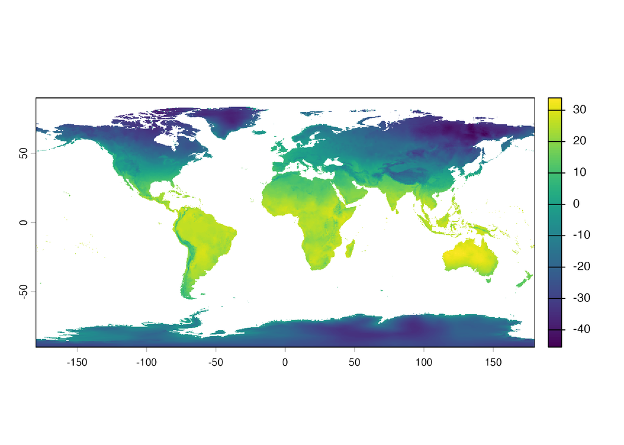

```r
plot(jan)
```

## 栅格投影演示

连续温度使用双线性重采样；投回原坐标也不会恢复全部原值。后续保留原始栅格分析。

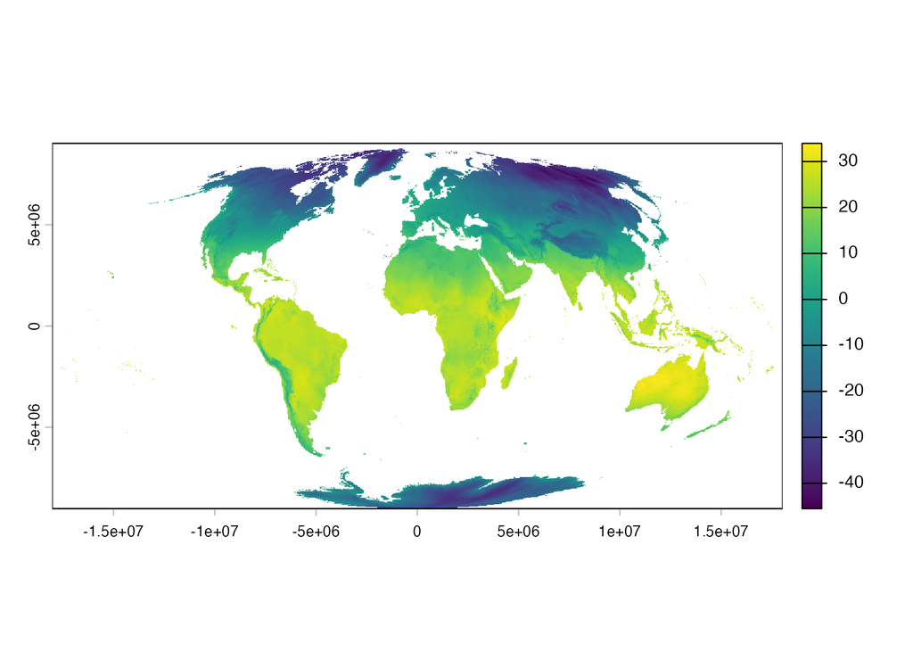

```r
moll <- "+proj=moll +lon_0=0 +datum=WGS84 +units=m +no_defs"
pr1 <- terra::project(jan, moll, method = "bilinear")
plot(pr1)
```

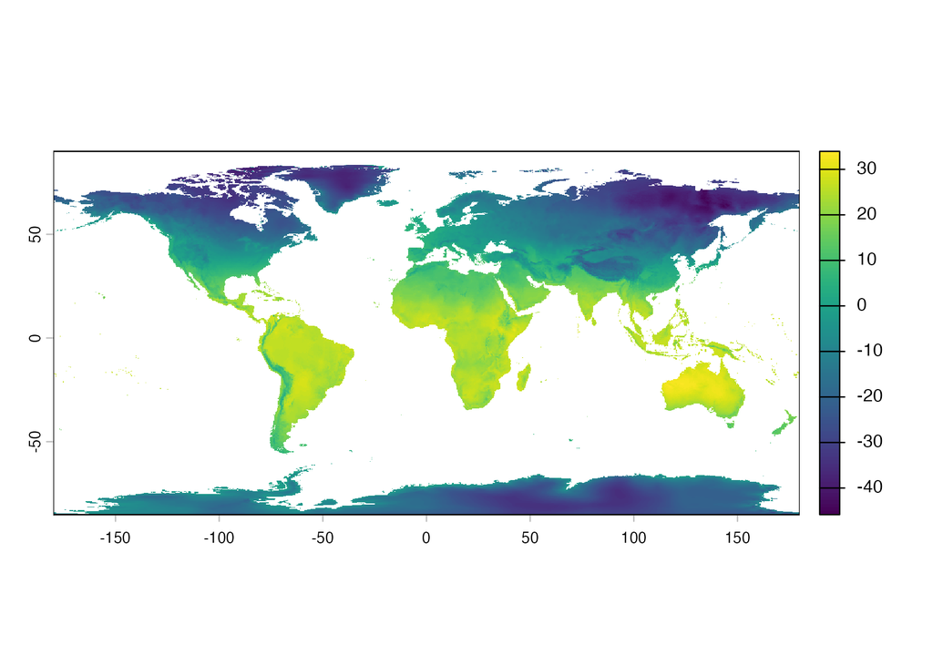

```r
pr_back <- terra::project(pr1, "EPSG:4326", method = "bilinear")
plot(pr_back)
```

## 3.5.3 十二个月图层

只匹配 tavg、5 角分的 12 个月文件，按月份顺序命名 Jan–Dec。

```r
file_info <- fs::dir_info(dirname(jan_file))
listfiles <- file_info %>%
  filter(str_detect(basename(path), "^wc2\\.1_5m_tavg_[0-9]{2}\\.tif$")) %>%
  arrange(path) %>% dplyr::select(path) %>% pull()
stopifnot(length(listfiles) == 12)
worldclimtemp <- terra::rast(as.character(listfiles))
stopifnot(terra::nlyr(worldclimtemp) == 12)
names(worldclimtemp) <- month.abb
worldclimtemp[[1]]
```

```
## class       : SpatRaster
## size        : 2160, 4320, 1  (nrow, ncol, nlyr)
## resolution  : 0.08333333, 0.08333333  (x, y)
## extent      : -180, 180, -90, 90  (xmin, xmax, ymin, ymax)
## coord. ref. : lon/lat WGS 84 (EPSG:4326)
## source      : wc2.1_5m_tavg_01.tif
## name        :        Jan
## min value   : -46.041999
## max value   :  34.064999
```

```r
worldclimtemp$Jan
```

```
## class       : SpatRaster
## size        : 2160, 4320, 1  (nrow, ncol, nlyr)
## resolution  : 0.08333333, 0.08333333  (x, y)
## extent      : -180, 180, -90, 90  (xmin, xmax, ymin, ymax)
## coord. ref. : lon/lat WGS 84 (EPSG:4326)
## source      : wc2.1_5m_tavg_01.tif
## name        :        Jan
## min value   : -46.041999
## max value   :  34.064999
```

## 3.5.4 城市提取

课堂 15 点按已知 CRS 转换后提取格值；Broome 纬度修正为 −17.96。格值不是城市行政区平均，海岸 NA 需核查。

```r
samples <- tibble(
  Site = c("Brisbane", "Melbourne", "Perth", "Sydney", "Broome", "Darwin", "Orange",
           "Bunbury", "Cairns", "Adelaide", "Gold Coast", "Canberra", "Newcastle", "Wollongong", "Logan City"),
  lon = c(153.03,144.96,115.86,151.21,122.23,130.84,149.10,115.64,145.77,138.6,153.43,149.13,151.78,150.89,153.12),
  lat = c(-27.47,-37.91,-31.95,-33.87,-17.96,-12.46,-33.28,-33.33,-16.92,-34.93,-28,-35.28,-32.93,-34.42,-27.64))
city_sf <- st_as_sf(samples, coords = c("lon", "lat"), crs = 4326)
city_sf <- st_transform(city_sf, terra::crs(worldclimtemp))
AUcitytemp <- terra::extract(worldclimtemp, terra::vect(city_sf))
stopifnot(nrow(AUcitytemp) == nrow(samples))
Aucitytemp2 <- bind_cols(samples %>% dplyr::select(Site), as_tibble(AUcitytemp) %>% dplyr::select(-ID))
Aucitytemp2
```

```
## # A tibble: 15 × 13
##    Site    Jan   Feb   Mar   Apr   May   Jun   Jul   Aug   Sep   Oct   Nov   Dec
##    <chr> <dbl> <dbl> <dbl> <dbl> <dbl> <dbl> <dbl> <dbl> <dbl> <dbl> <dbl> <dbl>
##  1 Bris…  25.5  25.2  24.2  21.7 18.8  15.7  14.7  15.5  18.1   20.8  22.9  24.7
##  2 Melb…  19.7  20.3  18.6  15.6 13.0  10.4   9.67 10.7  12.3   14.3  16.2  18.2
##  3 Perth  24.4  24.8  23.2  20.1 16.9  14.5  13.7  13.9  15.2   16.9  19.6  22.4
##  4 Sydn…  22.4  22.7  21.3  18.7 16.0  13.2  12.3  13.3  15.4   17.8  19.3  21.6
##  5 Broo…  29.6  29.3  29.5  28.5 25.3  22.4  21.6  22.8  25.3   27.8  29.2  29.9
##  6 Darw…  28.1  28.0  28.1  28.2 26.8  24.8  24.2  25.4  27.5   28.8  29.2  28.6
##  7 Oran…  19.8  19.6  17.0  12.9  9.33  6.27  5.20  6.33  8.96  12.1  14.9  18.1
##  8 Bunb…  22.6  22.9  21.5  18.6 15.8  13.7  12.8  13.0  14.2   15.6  18.1  20.5
##  9 Cair…  27.2  27.0  26.3  24.9 23.2  21.2  20.6  21.4  23.1   24.8  26.3  27.0
## 10 Adel…  21.0  21.6  19.4  16.4 13.8  11.3  10.5  11.4  13.0   15.2  17.5  19.6
## 11 Gold…  25.1  24.8  23.9  21.6 19.1  16.3  15.4  16.0  18.2   20.5  22.5  24.2
## 12 Canb…  20.2  20.1  17.7  13.6 10.2   6.89  5.83  7.29  9.92  12.9  15.6  18.6
## 13 Newc…  22.9  23.1  21.8  19.3 16.6  13.8  12.9  13.8  15.9   18.2  19.9  22.3
## 14 Woll…  21.8  22.1  20.8  18.4 15.8  13.2  12.4  13.2  15.2   17.3  18.7  21.0
## 15 Loga…  24.9  24.6  23.6  21.1 18.3  15.3  14.3  15.1  17.7   20.2  22.4  24.1
```

## 3.6 Perth 直方图

只选择月份温度列，频数单位为月份；breaks、counts、mids、density 分别为分箱、频数、中心和密度。

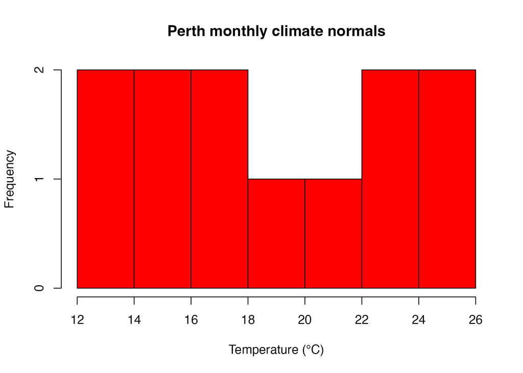

```r
Perthtemp <- Aucitytemp2 %>% filter(Site == "Perth")
stopifnot(nrow(Perthtemp) == 1)
perth_values <- Perthtemp %>% dplyr::select(all_of(month.abb)) %>% unlist(use.names = FALSE)
stopifnot(length(perth_values) == 12, is.numeric(perth_values))
hist(perth_values, col = "red", main = "Perth monthly climate normals", xlab = "Temperature (°C)")
```

```r
userbreak <- seq(floor(min(perth_values, na.rm = TRUE) / 2) * 2,
                 ceiling(max(perth_values, na.rm = TRUE) / 2) * 2 + 2, by = 2)
histinfo <- hist(perth_values, breaks = userbreak, plot = FALSE)
histinfo$breaks
```

```
## [1] 12 14 16 18 20 22 24 26 28
```

```r
histinfo$counts
```

```
## [1] 2 2 2 1 1 2 2 0
```

```r
histinfo$mids
```

```
## [1] 13 15 17 19 21 23 25 27
```

```r
histinfo$density
```

```
## [1] 0.08333333 0.08333333 0.08333333 0.04166667 0.04166667 0.08333333 0.08333333
## [8] 0.00000000
```

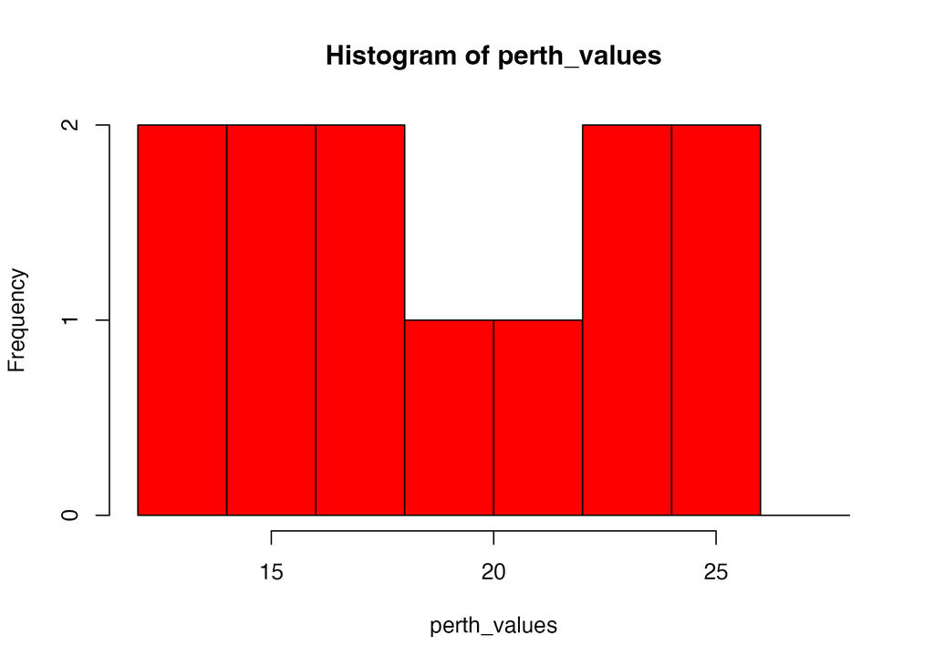

```r
plot(histinfo, col = "red")
```

## 全国裁剪与遮罩

`crop` 缩小矩形范围，`mask` 去掉国家边界外格子；简化边界仅用于显示。此处直方图频数单位为格子。

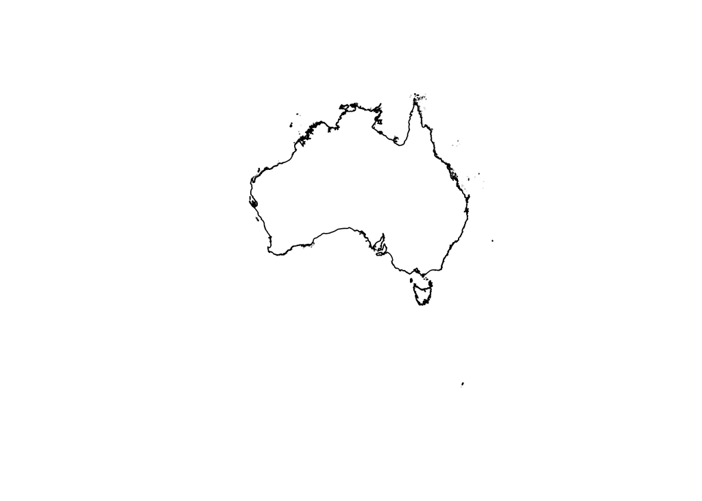

```r
plot(st_geometry(AusoutlinePROJECTED))
```

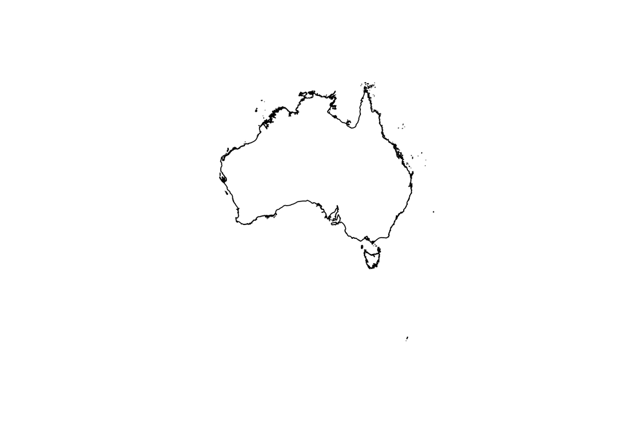

```r
AusoutSIMPLE <- st_simplify(AusoutlinePROJECTED, dTolerance = 1000, preserveTopology = TRUE)
plot(st_geometry(AusoutSIMPLE))
```

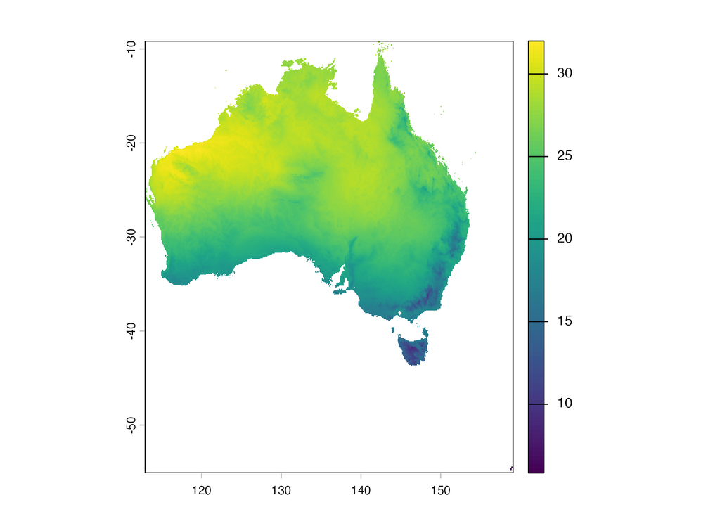

```r
aus_for_raster <- st_transform(Ausoutline, terra::crs(worldclimtemp))
Austemp <- terra::crop(worldclimtemp, terra::vect(aus_for_raster))
exactAus <- terra::mask(Austemp, terra::vect(aus_for_raster))
plot(exactAus$Mar)
```

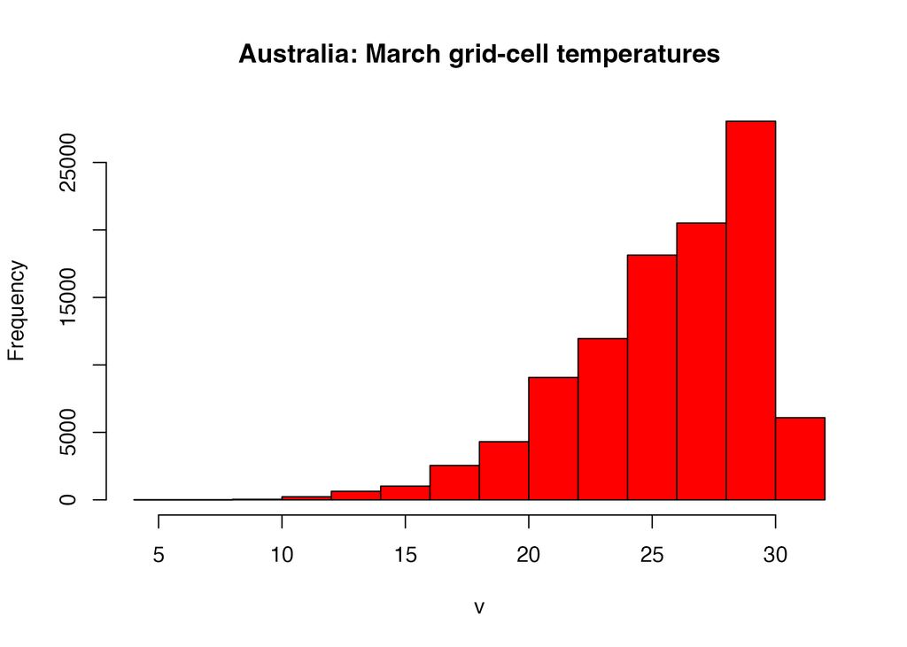

```r
hist(exactAus$Mar, col = "red", main = "Australia: March grid-cell temperatures")
```

## 长表、分面与统计

`Month` 为月份，`Temp` 为温度；统计为格子等权，未按面积、人口或月份天数加权。

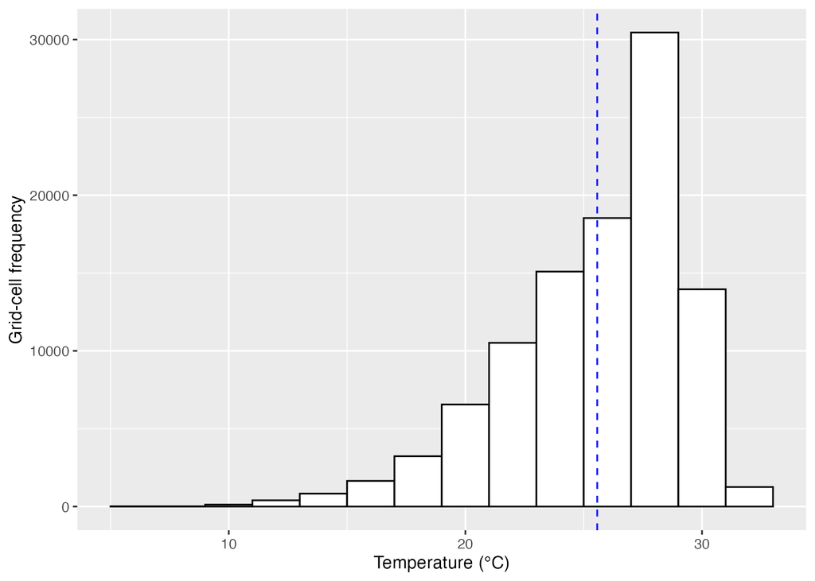

```r
exactAusdf <- as.data.frame(exactAus, na.rm = FALSE)
ggplot(exactAusdf, aes(x = Mar)) + geom_histogram(binwidth = 2, color = "black", fill = "white", na.rm = TRUE) +
  geom_vline(xintercept = mean(exactAusdf$Mar, na.rm = TRUE), linetype = "dashed", color = "blue") +
  labs(x = "Temperature (°C)", y = "Grid-cell frequency")
```

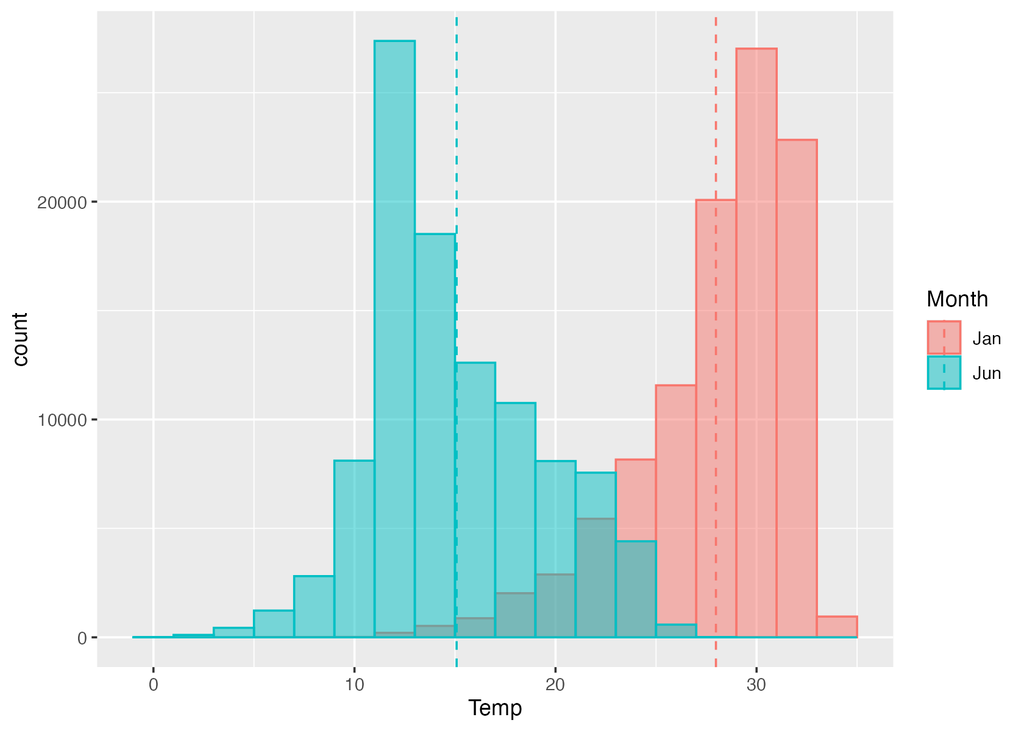

```r
squishdata <- exactAusdf %>% pivot_longer(all_of(month.abb), names_to = "Month", values_to = "Temp")
twomonths <- squishdata %>% filter(Month %in% c("Jan", "Jun")) %>% drop_na(Temp)
meantwomonths <- twomonths %>% group_by(Month) %>% summarise(mean = mean(Temp), .groups = "drop")
ggplot(twomonths, aes(Temp, fill = Month, color = Month)) +
  geom_histogram(position = "identity", alpha = 0.5, binwidth = 2) +
  geom_vline(data = meantwomonths, aes(xintercept = mean, color = Month), linetype = "dashed")
```

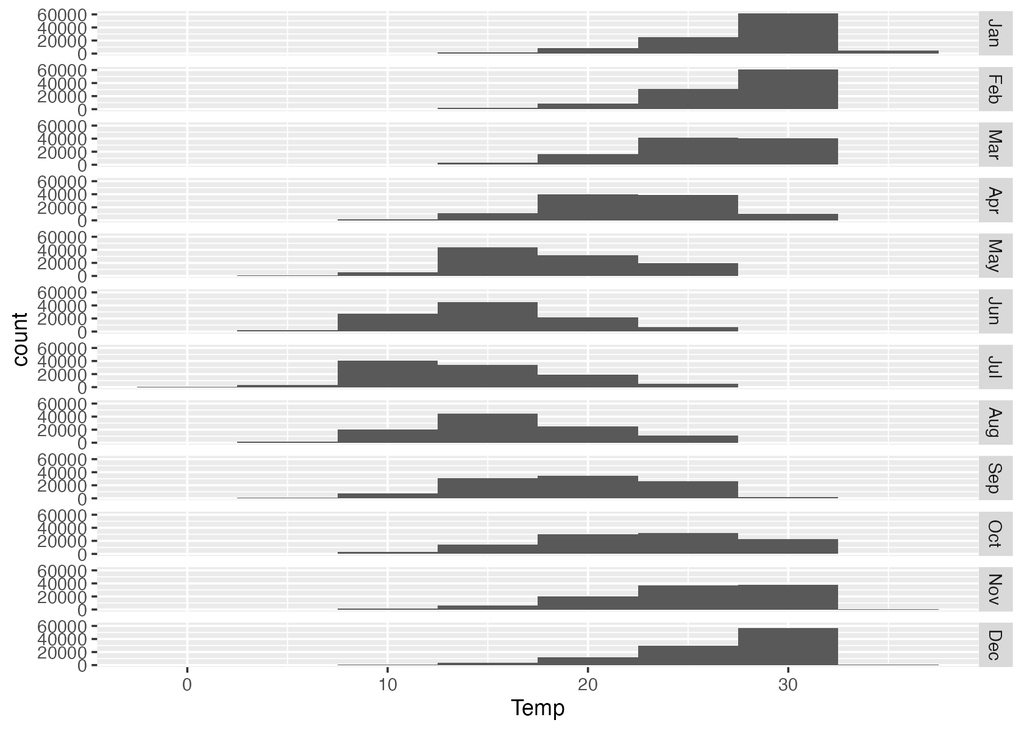

```r
data_complete_cases <- squishdata %>% drop_na(Temp) %>% mutate(Month = factor(Month, levels = month.abb))
ggplot(data_complete_cases, aes(Temp)) + geom_histogram(binwidth = 5) + facet_grid(Month ~ .)
```

```r
monthly_stats <- data_complete_cases %>% group_by(Month) %>%
  summarise(n = n(), mean = mean(Temp), sd = sd(Temp), min = min(Temp), max = max(Temp), IQR = IQR(Temp), .groups = "drop")
monthly_stats
```

```
## # A tibble: 12 × 7
##    Month      n  mean    sd    min   max   IQR
##    <fct>  <int> <dbl> <dbl>  <dbl> <dbl> <dbl>
##  1 Jan   102598  28.0  3.86  6.49   34.1  4.81
##  2 Feb   102598  27.4  3.48  6.53   32.9  4.22
##  3 Mar   102598  25.6  3.72  5.85   32.0  5.05
##  4 Apr   102598  22.2  4.12  4.57   30.4  6.33
##  5 May   102598  18.3  4.17  2.64   28.8  5.94
##  6 Jun   102598  15.1  4.23 -0.394  27.2  5.64
##  7 Jul   102598  14.3  4.31 -2.08   26.4  5.68
##  8 Aug   102598  15.9  4.51 -1.50   26.4  6.40
##  9 Sep   102598  19.3  4.86  0.776  29.6  7.30
## 10 Oct   102598  22.6  5.02  3.26   32.1  7.81
## 11 Nov   102598  25.1  4.75  4.01   33.1  7.03
## 12 Dec   102598  27.0  4.23  5.52   32.9  5.67
```

```r
data_complete_cases %>% summarise(meanwholeyear = mean(Temp))
```

```
## # A tibble: 1 × 1
##   meanwholeyear
##           <dbl>
## 1          21.7
```

## 扩展：栅格图与交互直方图

使用 tidyterra 与 plotly，比较一月和六月的格网温度分布。

```r
gis_packages(c("plotly", "tidyterra"))
ggplot() + tidyterra::geom_spatraster(data = exactAus, aes(fill = Mar))
jan_values <- filter(data_complete_cases, Month == "Jan")$Temp
jun_values <- filter(data_complete_cases, Month == "Jun")$Temp
plotly::plot_ly(alpha = 0.6) %>%
  plotly::add_histogram(x = jan_values, name = "January", xbins = list(size = 2.5)) %>%
  plotly::add_histogram(x = jun_values, name = "June", xbins = list(size = 2.5)) %>%
  plotly::layout(barmode = "overlay", xaxis = list(title = "Temperature (°C)"), yaxis = list(title = "Grid-cell frequency"))
```

[output not shown]

## Homework 与阅读

未来 tmax 的 SSP126/SSP585 比较见 homework.Rmd，与课堂历史 tavg 分开。概念见 lecture-notes.Rmd，课堂结果见 运行记录。阅读：Navarro 描述统计第 5 章、Geocomputation with R 重投影章节。

## 资料链接

- [官方第 3 章](https://andrewmaclachlan.github.io/CASA0005repo/spatial-descriptive-statistics.html)
- [CC BY-SA 4.0](https://creativecommons.org/licenses/by-sa/4.0/)
- [GADM](https://gadm.org/download_country.html)
- [WorldClim v2.1](https://www.worldclim.org/data/worldclim21.html)
- [未来数据](https://www.worldclim.org/data/cmip6/cmip6climate.html)